# Playing With Scraping & Sentiment Analysis

Jordan D. Snyder

18 July, 2020

[interactive chart not shown]

Figure 1. A wordcloud of all text in your blogposts.

This is a wordcloud of all of the text from all of your blogposts. I scraped this from your website. It should create a different wordcloud each time you look at the page.

I will also be conducting sentiment analysis, which seeks to determine the emotional content of the text.

```
## [1] "factor"
```

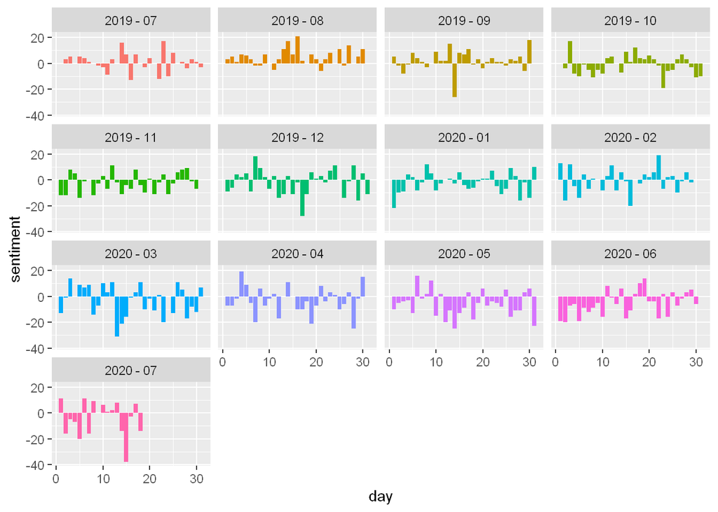

This is sentiment level by day across the different months of your blog. This is based on individual words (and thus does not take negation into account).

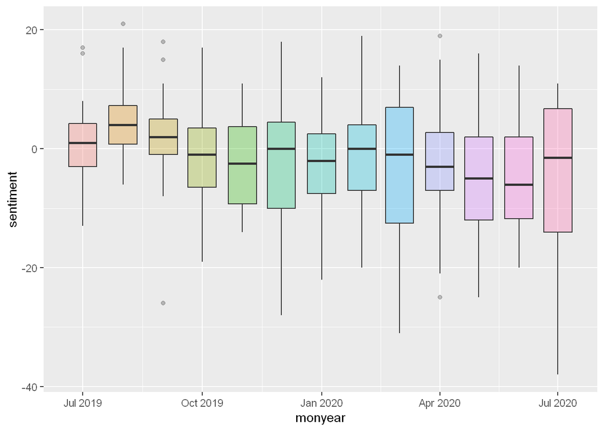

This is the average sentiment across months. Looks like it gets a bit more negative as time goes on. Again, this is limited in the fact that it does not account for negation.

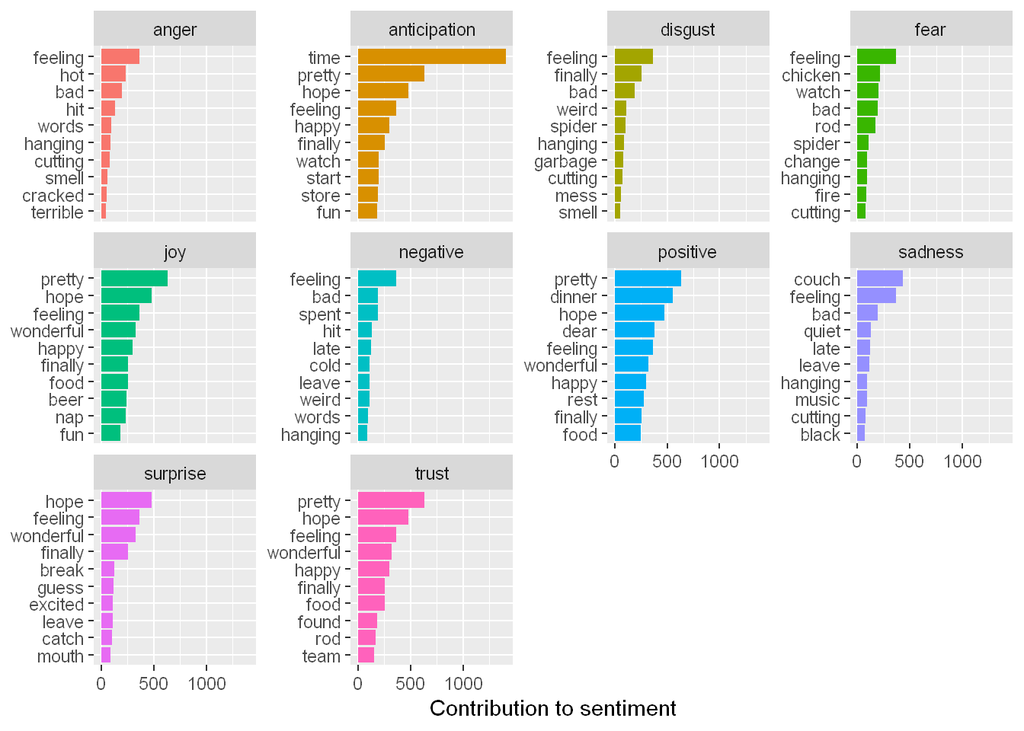

This breaks up sentiment analysis into something more than just positive and negative, but attempts to break it up into other emotions. I don’t quite understand how they get some of these and some may not be appropriate (e.g., I imagine you use chicken in discussing food and not that someone is a chicken).

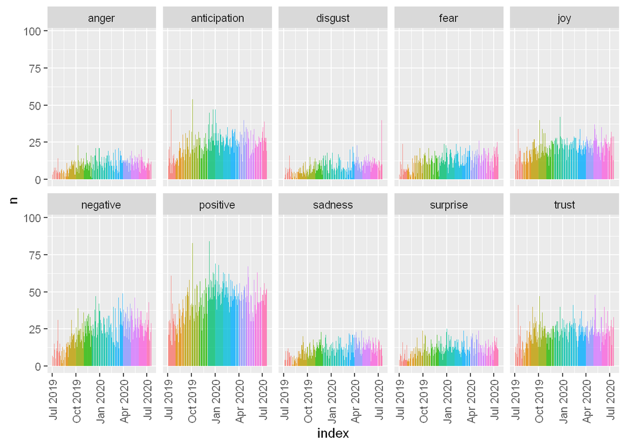

I made this one because of the cool colours. Sentiment is colored by month. Not necessarily too helpful…

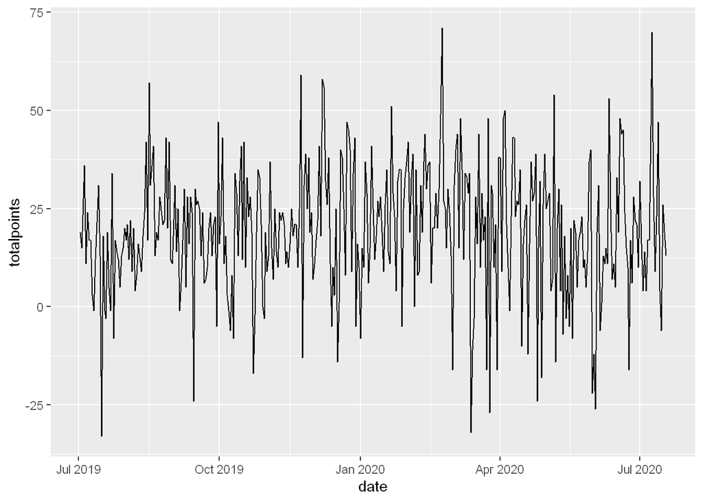

This uses a different sentiment analysis that weights words on emotions from very positive (5) to very negative (-5) and then creates scores based upon this.

Highest Ranked Entries Based Upon NRC + AFINN

| date | sentiment | totalpoints | text |
| --- | --- | --- | --- |
| 2020-05-06 | 16 | 54 | nurses zoom calls and portillo’s |
| 2019-12-07 | 18 | 58 | packing monster trucks traffic and chicago |
| 2020-04-04 | 19 | 50 | leftovers catch and eyeball touching |
| 2019-08-16 | 21 | 57 | naps pizza walks drinking and wrestling |

| date | sentiment | totalpoints | text |
| --- | --- | --- | --- |
| 2020-05-31 | -23 | -22 | riots picnics baby ducks and half-dead shrimp |
| 2020-04-28 | -25 | -18 | automation poop stress and too much mustard |
| 2019-09-14 | -26 | -24 | outages |
| 2020-03-13 | -31 | -32 | apple crappies water bottle flips and a note on hoarding |

This above table is the top positive posts (on a couple of different measures of sentiment) while the bottom table is the top negative posts.

The negative posts generally make sense (the one on people hoarding supplies on 3/13, network outage issues on 9/14, and issues with riots on 5/31).

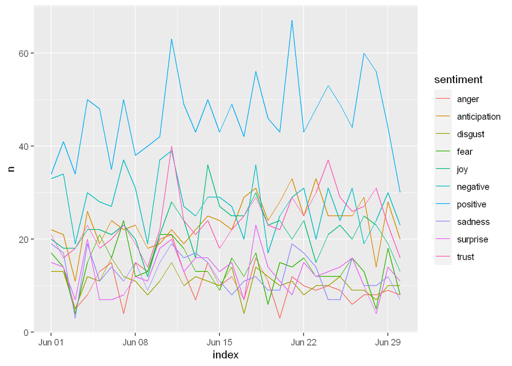

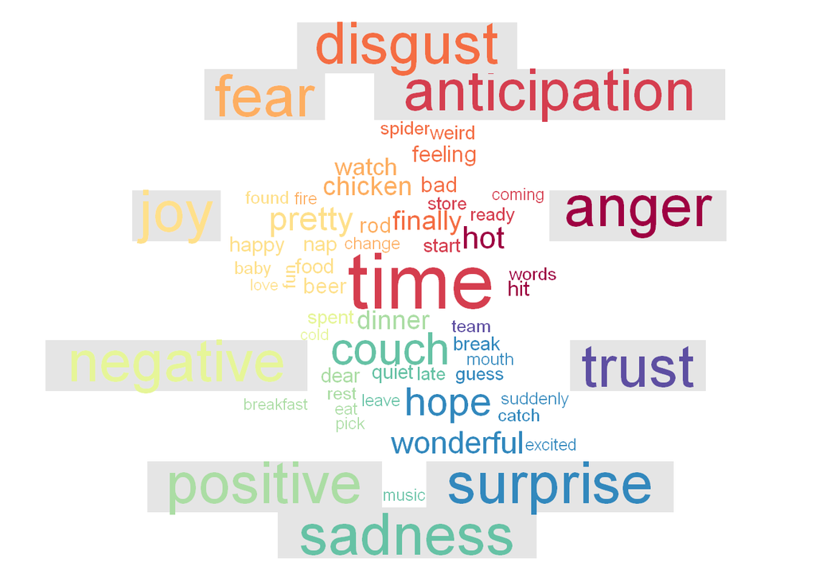

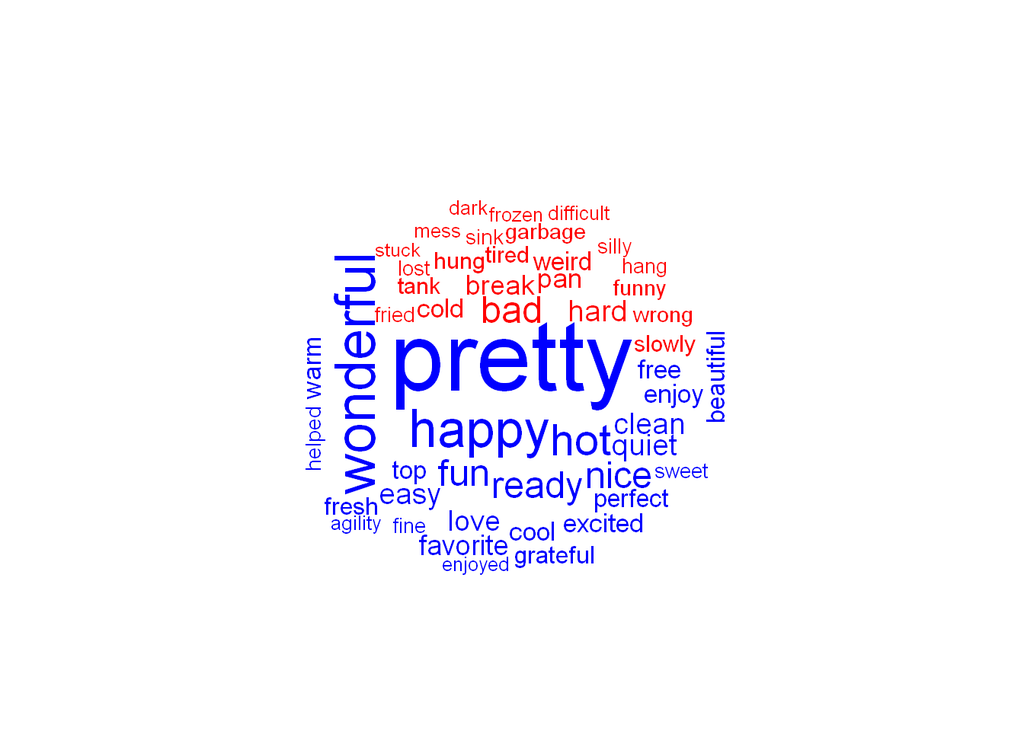

This created three images. First, this is a graph over the month of June of several different sentiments, and then a wordcloud of words associated with these sentiments. Finally, there is a sentiment wordcloud of positive and negative words.

```
## # A tibble: 256 x 3
##    word1 word2     n
##    <chr> <chr> <int>
##  1 not   to       48
##  2 not   a        37
##  3 not   going    30
##  4 not   even     29
##  5 not   only     24
##  6 not   sure     22
##  7 not   the      19
##  8 not   just     15
##  9 not   that     14
## 10 not   as       12
## # ... with 246 more rows
```

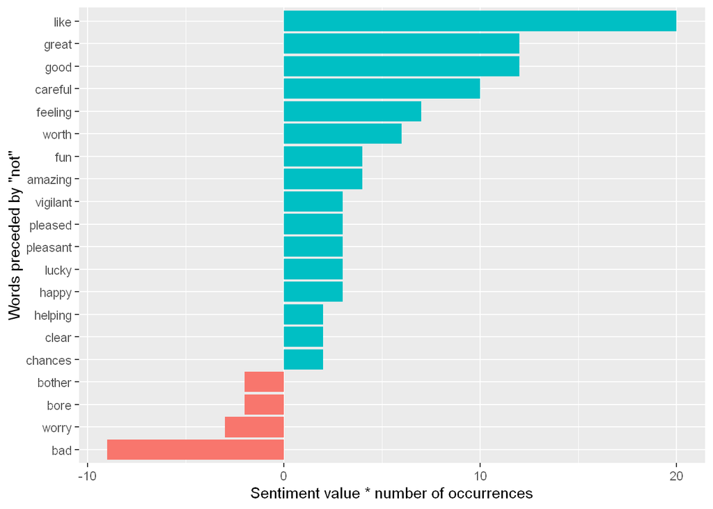

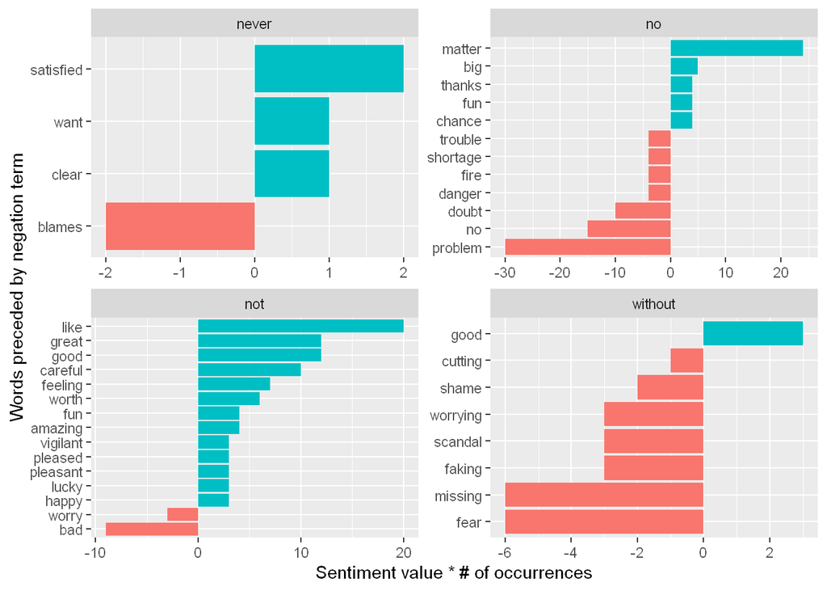

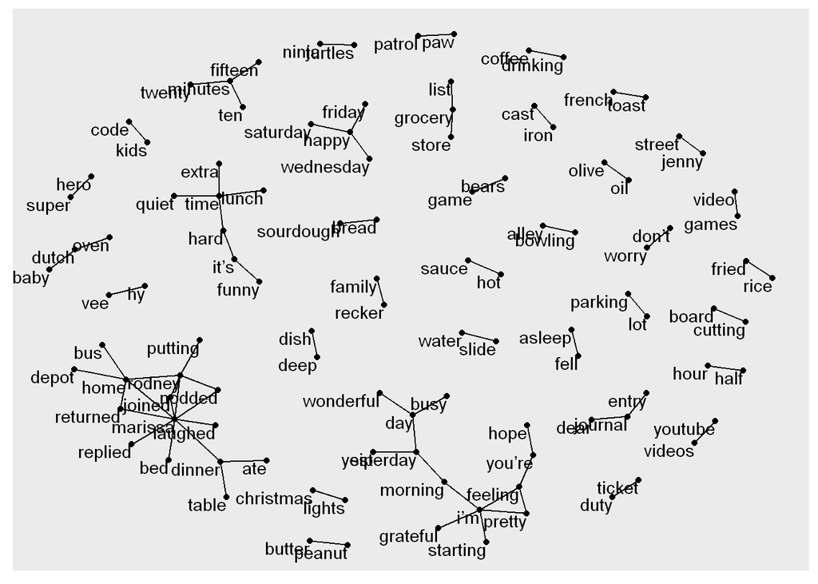

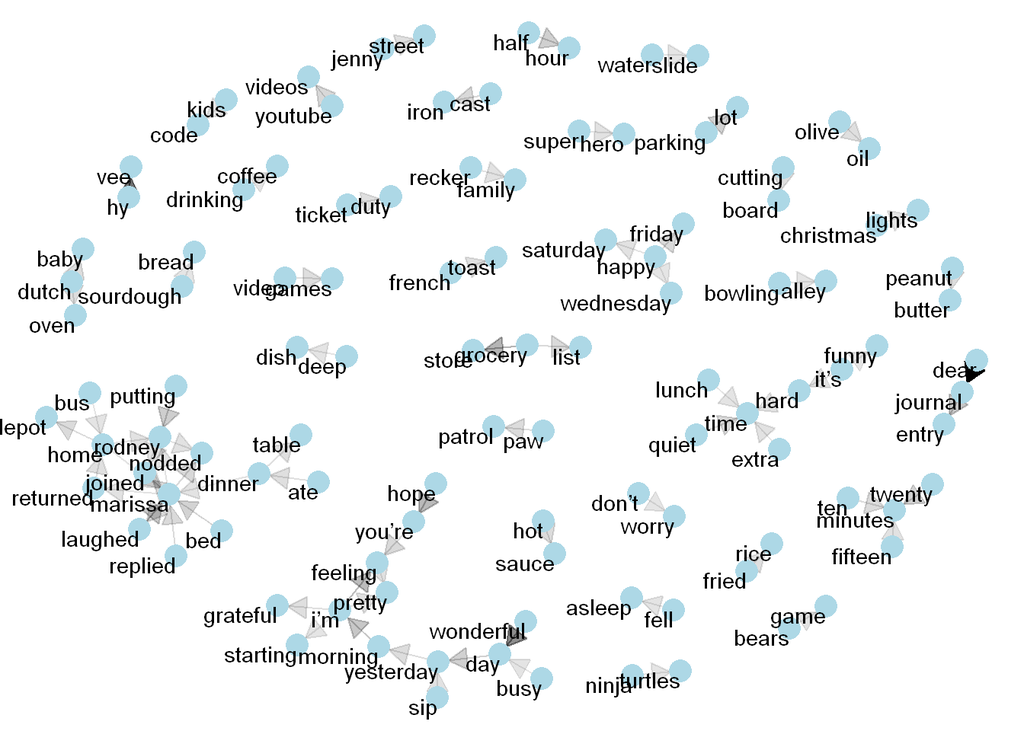

This analyzed words in pairs instead of by themselves. The first graph shows words that were preceded by not, while the second shows all ‘negation’ words the preceded important words. The next two graphs are networks which show words that are associated with each other. Not surprising that ‘hy’ and ‘vee’ are associated with each other. Also, I love seeing all of the words associated with Marissa and Rodney (laugh, dinner, etc.).

This is a quick analysis of your text and scraping. I put this together as I saw that you were interested in how your data may be used, and this is one way that people may use it.